# chapter3.Rmd

Frida Gyllenberg

22 Nov 2017

## The data

The data set I will use for this exercise is a combination of two data sets on student achievement in secondary education of two Portuguese schools. Data were collected by using school reports and questionnaires. THe two data sets regards maths and Portugese. In the combination of the two data set variables not used for joining have been combined by averaging. Two new variables have been computed;‘alc_use’ is the average of ‘Dalc’ and ‘Walc’ and ‘high_use’ is TRUE if ‘alc_use’ is higher than 2 and FALSE otherwise.

```r
alc <- read.csv("~/Dropbox/Abortforskning/opendatascience/IODS_project/data/alc.csv", header = TRUE, sep = ",")
dim(alc)
```

```
## [1] 382  35
```

```r
colnames(alc)
```

```
##  [1] "school"     "sex"        "age"        "address"    "famsize"
##  [6] "Pstatus"    "Medu"       "Fedu"       "Mjob"       "Fjob"
## [11] "reason"     "nursery"    "internet"   "guardian"   "traveltime"
## [16] "studytime"  "failures"   "schoolsup"  "famsup"     "paid"
## [21] "activities" "higher"     "romantic"   "famrel"     "freetime"
## [26] "goout"      "Dalc"       "Walc"       "health"     "absences"
## [31] "G1"         "G2"         "G3"         "alc_use"    "high_use"
```

## Hypothesis regarding high use of alcohol

I choose to look at four different variables and to investigate their relationship with high use of alcohol with the following hypthesis; i) sex: I assume high use of alcohol is more prevalent among men ii) absences: my hypotheisis is that high use is associated with more absence from school iii) activities: high use of alcohol could be related to less extra-curricular actyivities iv) G3 i.e. Final grade: high use during school could resoult in lower grades.

## Exploring my chosen variables numerically and graphically

I start by plotting the two numeric variables in a box plot. Regarding grades, the mean grade is lower ammong students woth high alcohol use. Student absences on the other hand are more frequent among students with high use of alcohol.

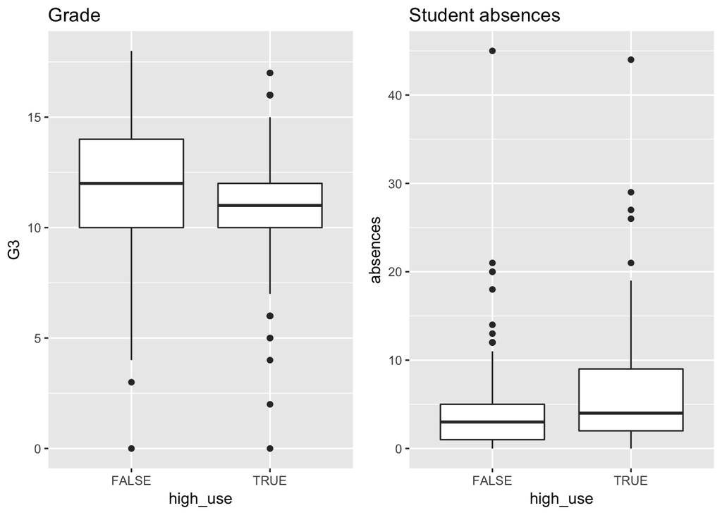

```r
g1 <- ggplot(alc, aes(x = high_use, y = G3))+ geom_boxplot() + ggtitle("Grade")
g2 <- ggplot(alc, aes(x=high_use, y=absences)) + geom_boxplot()+ggtitle("Student absences")
grid.arrange(g1, g2, nrow=1, ncol=2)
```

```r
print("Cross tabulation of alcohol use by sex")
```

```
## [1] "Cross tabulation of alcohol use by sex"
```

```r
table(alc$high_use, alc$sex)
```

```
##
##           F   M
##   FALSE 156 112
##   TRUE   42  72
```

```r
print("Cross tabulation of alcohol use by activities")
```

```
## [1] "Cross tabulation of alcohol use by activities"
```

```r
table(alc$high_use, alc$activities)
```

```
##
##          no yes
##   FALSE 122 146
##   TRUE   59  55
```

## Logistic regression

modeling a logistic regression on the target variable high_use and my four chosen variables as explanatory variables. Here are the Odds Ratio (i.e. exponent of the model estimates ) with 95% confidence intervals

```r
m <- glm(high_use ~ absences + sex + activities + G3, data = alc, family = "binomial")
cbind(coef(m), confint(m))%>% exp %>% round(4)
```

```
##                       2.5 % 97.5 %
## (Intercept)   0.4198 0.1661 1.0379
## absences      1.0975 1.0513 1.1505
## sexM          2.7800 1.7340 4.5234
## activitiesyes 0.7138 0.4444 1.1421
## G3            0.9315 0.8675 0.9995
```

The OR for absences is 1.10, i.e. for every unit of abscense the odds of being a high user is 10 % higher. Compared to females, the odds are 2.8-fold for males to be high users. Regarding activities, the result is insignificant, and for the grade there is maybe some relation to lower grades as the OR is 0.93, but UCI is approaching 1 (0.9995)

## Predictive power of the model

```r
# predict() the probability of high_use
probabilities <- predict(m, type = "response")

# add the predicted probabilities to 'alc'
alc <- mutate(alc, probability = probabilities)

# use the probabilities to make a prediction of high_use
alc <- mutate(alc, prediction = probability>0.5)

# tabulate the target variable versus the predictions
table(high_use = alc$high_use, prediction=alc$prediction)
```

```
##         prediction
## high_use FALSE TRUE
##    FALSE   256   12
##    TRUE     87   27
```

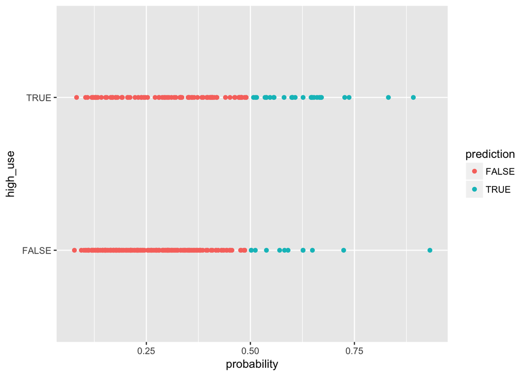

```r
# initialize a plot of 'high_use' versus 'probability' in 'alc'
ggplot(alc, aes(x = probability, y = high_use, col=prediction)) +
  geom_point()
```

The the model found accurately 256 out of 268 non-high-users, but only 27 out of 114 true high-users. So, it is not a very good predictive model…

### This is it for tonight, sorry no bonuses for me:)